# Przetwarzanie, analiza i wizualizacja danych przestrzennych w języku R

Kurs Uniwersytetu Otwartego UAM  
Zajęcia 2 - Manipulacja i eksploracja danych

Author

**Adrian Nowacki** (adrian.nowacki@amu.edu.pl)

Published

April 2, 2025

# Wprowadzenie

Z poprzednich zajęć dowiedzieliśmy się najważniejszych podstaw języka R – typów i struktur danych, sposobów ich tworzenia i selekcji, a także definiowania warunków, pętli oraz funkcji. Zajęcia 2 obejmują eksploracyjną analizę i wizualizację danych tabelarycznych, a także wszelkie operacje na ramkach danych, takie jak filtrowanie, sortowanie, grupowanie, agregacja czy łączenie tabel. Dzięki temu w następnych zajęciach będziemy mogli płynnie przejść do przetwarzania i analizy danych wektorowych, które wykorzystują struktury tabelaryczne do przechowywania atrybutów.

### Instalacja wymaganych pakietów

Na początek zainstalujemy pakiet *tidyverse* który jest zestawem kilku bardzo przydatnych pakietów w jednym, m.in.:

- **ggplot2** – do wizualizacji danych
- **dplyr** – do manipulacji danymi (filtrowanie, grupowanie, agregacja)
- **tidyr** – do przekształcania i czyszczenia danych
- **readr** – do wczytywania danych z plików tekstowych (CSV)
- **stringr** – do pracy z tekstami i wyrażeniami regularnymi

```r
#install.packages("tidyverse")
library(tidyverse)
```

### Gotowe zestawy danych

Za pomocą pakietu `datasets` mamy bezpośredni dostęp do kilkudziesięciu gotowych zbiorów danych, które są wykorzystywane głównie w celach tutorialowych. Wszystkie dostępne zbiory można wyświetlić za pomocą funkcji `data()`

```r
data()
```

Na potrzeby dzisiejszych zajęć skorzystamy m.in. ze zbioru *airquality*, przechowującego dane dotyczące miar jakości powietrza w Nowym Jorku od maja do września 1973 roku.

```r
airquality <- airquality
```

Aby sprawdzić strukturę załadowanego zbioru, możemy użyć funkcji poznanych na wcześniejszych zajęciach. Dla lepszego, wizualnego odbioru, możemy wyświetlić zbiór z panelu zmiennych (działa też funkcja `View(airquality)`).

```r
str(airquality)
```

```
'data.frame':   153 obs. of  6 variables:
 $ Ozone  : int  41 36 12 18 NA 28 23 19 8 NA ...
 $ Solar.R: int  190 118 149 313 NA NA 299 99 19 194 ...
 $ Wind   : num  7.4 8 12.6 11.5 14.3 14.9 8.6 13.8 20.1 8.6 ...
 $ Temp   : int  67 72 74 62 56 66 65 59 61 69 ...
 $ Month  : int  5 5 5 5 5 5 5 5 5 5 ...
 $ Day    : int  1 2 3 4 5 6 7 8 9 10 ...
```

```r
head(airquality)
```

```
  Ozone Solar.R Wind Temp Month Day
1    41     190  7.4   67     5   1
2    36     118  8.0   72     5   2
3    12     149 12.6   74     5   3
4    18     313 11.5   62     5   4
5    NA      NA 14.3   56     5   5
6    28      NA 14.9   66     5   6
```

Jak możemy przeczytać w dokumentacji zbioru (wykonując polecenie `?airquality`), pozyskany zbiór charakteryzuje się sześcioma kolumnami:

- **Ozone** – stężenie ozonu (ppb)
- **Solar.R** – promieniowanie słoneczne (langley)
- **Wind** – prędkość wiatru (mph)
- **Temp** – temperatura (°F)
- **Month** – miesiąc (1–12)
- **Day** – dzień miesiąca (1–31)

# Przygotowanie do manipulacji danych

### Wczytywanie i zapisywanie danych tabelarycznych

Do R można wczytać pliki .csv oraz .xslx, na których wcześniej pracowano np. w programie MS Excel. Wczytany plik zostanie od razu przypisany do struktury ramki danych.

Przed wczytywaniem i zapisywaniem plików warto sprawdzić, czy znajdujemy się w odpowiednim folderze – pomimo poprawnego kodu ścieżka może być nieprawidłowa (katalog roboczy może być ustawiony w innym miejscu, niż folder z naszą ścieżką do pliku), po czym R wypluje błąd o nieprawidłowej ścieżce lub nieistniejącym pliku. Ścieżkę folderu roboczego można sprawdzić za pomocą funkcji `getwd()`, a aby przypisać nową ścieżkę do folderu roboczego należy użyć `setwd()` lub zrobić to ręcznie w prawym dolnym panelu “Files -> Go to directory”, a następnie po wyborze odpowiedniego folderu kliknąć koło zębate “More file commands -> Set as working directory”:

```r
getwd()
```

```
[1] "E:/studia_doktorskie/rok_I/kurs_uo/html"
```

```r
setwd("E:/studia_doktorskie/rok_I/kurs_uo/html/02_eksploracja_danych")
```

##### .csv

Aby wczytać i zapisać plik .csv, można użyć wbudowanych funkcji R – `read.csv()` i `write.csv()`. Mając wczytany zbiór danych `airquality`, możemy zapisać go do pliku .csv, a następnie go wczytać. Pierwszym argumentem funkcji `write.csv()` jest nasza ramka danych, drugim ścieżka z rozszerzeniem pod którym chcemy go zapisać, a argument `row.names = FALSE` określa, że do naszej ramki danych nie doda się zbędna kolumna z ID wierszy:

```r
write.csv(airquality, "airquality.csv", row.names = FALSE)

csv <- read.csv("airquality.csv")
csv <- read.csv("airquality.csv", sep = ";")             # wczytanie danych o innym separatorze niż przecinek
```

##### .xlsx – arkusz kalkulacyjny

W przypadku plików .xlsx należy zainstalować pakiety obsługujące ich poprawne wczytywanie. Do takich pakietów należy m.in `openxlsx`, ale także `writexl` i `readxl`.

```r
#install.packages("openxlsx")
library(openxlsx)

write.xlsx(airquality, "airquality.xlsx")
xlsx <- read.xlsx("airquality.xlsx")
```

Istnieją także dodatkowe opcje dla arkuszy kalkulacyjnych:

```r
getSheetNames("plik.xlsx")                                              # podgląd dostępnych arkuszy z pliku
xlsx <- read.xlsx("airquality.xlsx", sheet = 1)                         # wczytanie wybranego arkusza z pliku
write.xlsx(list(arkusz_1 = csv, arkusz_2 = xlsx), "arkusze.xlsx")       # zapisanie kilku ramek danych jako osbne arkusze
```

### Potoki

Operatory potoku służą do przekazywania wyniku jednej funkcji jako pierwszy argument kolejnej funkcji, co znacznie skraca kod i poprawia jego czytelność kodu. Operatory potoku są szczególnie używane razem z funkcjami manipulującymi danymi tabelarycznymi z pakietu *dplyr*, czyli razem z filtrowaniem, grupowaniem, selekcją itd. Dlatego też przed rozpoczęciem pełnych operacji na tabelach, warto się z nimi zapoznać. W R wyróżniamy dwa główne potoki, które lekko się między sobą różnią:

- **%>%** – potok z pakietu dplyr, pozwala przekazać wynik do dowolnego argumentu funkcji za pomocą **.**, jednak takie wyrażenia są bardziej skomplikowane

Klasyczne podejście – wektor *temperatury* jest pierwszym argumentem funkcji `mean()`:

```r
temperatury <- head(airquality$Temp)

mean(temperatury)
```

```
[1] 66.16667
```

Podejście z użyciem potoku – wektor *temperatury* jest przekazywany jako argument funkcji `mean()`, dlatego nie musimy definiować nic w jej środku:

```r
temperatury %>%
  mean()
```

```
[1] 66.16667
```

- **|>** – potok bazowego R wprowadzony od wersji 4.1, wynik musi być pierwszym argumentem następnej funkcji

```r
temperatury |>
  mean()
```

```
[1] 66.16667
```

W naszym przypadku oba potoki działają identycznie, ponieważ wektor *temperatury* jest dla funkcji `mean()` pierwszym parametrem – co innego byłoby w sytuacji, kiedy używamy wyniku poprzedniej funkcji w dalszych parametrach nowej funkcji. Na potrzeby szkolenia możemy jednak korzystać zarówno z `%>%`, jak i `|>`.

Użycie operatorów potoku jest bardzo przydatne do łączenia wielu operacji, ponieważ nasz kod wygląda wówczas czytelniej. Poniżej przykład dla zaokrąglenia średniej pierwiastków kwadratowych:

```r
vec <- c(4.5, 9.4, 15, 20.45, 30)

# klasyczne podejście
round(mean(sqrt(vec)), 2)
```

```
[1] 3.81
```

```r
# podejście z użyciem %>% lub |>
vec %>%
  sqrt() %>%         # pierwiastek kwadratowy
  mean() %>%         # średnia z otrzymanych wartości
  round(2)           # zaokrąglenie średniej do 2 miejsc po przecinku
```

```
[1] 3.81
```

# Manipulacja danymi tabelarycznymi

Aby zbiór danych został poprawnie przeanalizowany i zwizualizowany, musi być najpierw poddany odpowiedniemu przygotowaniu. W tej sekcji zawarto informacje o najbardziej przydatnych operacjach na ramkach danych, które są niezbędne w ich późniejszej analizie.

### 1. Sprawdzenie braków danych

Braki danych (`NA`) mogą prowadzić do niepoprawnych analiz, dlatego warto sprawdzić, czy występują one w naszym zestawie. Jeśli jest ich niewiele i są one zbędne, warto je usunąć lub zastąpić średnią lub medianą dla całego zbioru, jeśli natomiast jest ich dużo – warto się przyjrzeć, czy dane zostały przygotowane poprawnie i czy duża liczba braków danych nie wpłynie negatywnie na wyniki analiz.

Do sprawdzenia braków danych stosuje się funkcję `is.na`. Zwraca ona informację, czy w danym elemencie znajduje się brak danych (TRUE), czy nie (FALSE).

```r
head(is.na(airquality))
```

```
     Ozone Solar.R  Wind  Temp Month   Day
[1,] FALSE   FALSE FALSE FALSE FALSE FALSE
[2,] FALSE   FALSE FALSE FALSE FALSE FALSE
[3,] FALSE   FALSE FALSE FALSE FALSE FALSE
[4,] FALSE   FALSE FALSE FALSE FALSE FALSE
[5,]  TRUE    TRUE FALSE FALSE FALSE FALSE
[6,] FALSE    TRUE FALSE FALSE FALSE FALSE
```

Do sprawdzenia, ile braków danych znajduje się w każdej kolumnie naszego zbioru, można skorzystać z funkcji `ColSums`, która sumuje wartości danej kolumny spełniające określony warunek.

```r
colSums(is.na(airquality))
```

```
  Ozone Solar.R    Wind    Temp   Month     Day
     37       7       0       0       0       0
```

Jeśli chcemy usunąć z naszego zbioru braki danych, możemy użyć funkcji `na.omit()`:

```r
airquality <- na.omit(airquality)
```

### 2. Filtrowanie danych

Filtrowanie pozwala wybrać tylko te obserwacje, które spełniają określone warunki. Do filtrowania danych możemy użyć albo indeksowania (poznanego na poprzednich zajęciach), albo funkcji `filter()` z pakietu *dplyr*, która jest bardziej intuicyjna.

Aby wybrać np. tylko te dni, w których panowała temperatura powyżej 95°F, można użyć indeksowania:

```r
airquality[airquality$Temp > 95,]
```

```
    Ozone Solar.R Wind Temp Month Day
120    76     203  9.7   97     8  28
122    84     237  6.3   96     8  30
```

lub filtrowania przy użyciu `filter()`:

```r
# klasyczne podejście
filter(airquality, Temp > 95)
```

```
  Ozone Solar.R Wind Temp Month Day
1    76     203  9.7   97     8  28
2    84     237  6.3   96     8  30
```

```r
# podejście z użyciem %>% lub |>
airquality %>% filter(Temp > 95)
```

```
  Ozone Solar.R Wind Temp Month Day
1    76     203  9.7   97     8  28
2    84     237  6.3   96     8  30
```

W bardziej intuicyjny sposób działa także filtrowanie wielu kolumn jednocześnie. Dla przykładu poniżej ukazano wybór tylko lipcowych dni z poziomem ozonu powyżej 100 ppb.

```r
airquality %>% filter(Month == 7, Ozone > 100)
```

```
  Ozone Solar.R Wind Temp Month Day
1   135     269  4.1   84     7   1
2   108     223  8.0   85     7  25
```

### 3. Selekcja kolumn

Często zdarza się, że nie wszystkie kolumny zbioru danych są potrzebne do analizy, dlatego warto wybrać jedynie te, które nas interesują. Możemy to zrobić albo za pomocą indeksowania, albo za pomocą funkcji `select()`, również z pakietu *dplyr* wchodzącego w skład *tidyverse*.

Indeksowanie:

```r
# pojedynczy wybór
solar <- airquality$Solar.R

# wielokrotny wybór
selected_data <- airquality[, c("Ozone", "Temp", "Month", "Day")]
```

```r
# usunięcie ozonu z zestawu danych
airquality_selected <- airquality %>% select(-Solar.R)

# LUB wybór wszystkich interesujących zmiennych
airquality_selected <- airquality %>% select(Ozone, Wind, Temp, Month, Day)
head(airquality_selected)
```

```
  Ozone Wind Temp Month Day
1    41  7.4   67     5   1
2    36  8.0   72     5   2
3    12 12.6   74     5   3
4    18 11.5   62     5   4
7    23  8.6   65     5   7
8    19 13.8   59     5   8
```

### 4. Edycja kolumn

Kolumny ramki danych mogą być usuwane, dodawane oraz jakkolwiek edytowane. Już wiemy, jak za pomocą indeksowania lub funkcji `select()` usunąć wybrane kolumny – aby dodać kolumny, również możemy użyć zarówno indeksowania, jak i funkcji z pakietu *dplyr* – `mutate()`.

Używając indeksowania, możemy dodać nową kolumnę pisząc jej nazwę w nawiasach kwadratowych `[]` lub za znakiem dolara `$`:

```r
# przypisanie zbioru danych do próbnej zmiennej
dat_1 <- airquality_selected

# dodanie kolumny używając indeksowania
dat_1["zmienna_1"] <- "zmienna"       # dodanie kolumny "zmienna_1"
dat_1$zmienna_1 <- "edytowana zmienna"          # edycja dodanej kolumny "zmienna_1"
head(dat_1)
```

```
  Ozone Wind Temp Month Day         zmienna_1
1    41  7.4   67     5   1 edytowana zmienna
2    36  8.0   72     5   2 edytowana zmienna
3    12 12.6   74     5   3 edytowana zmienna
4    18 11.5   62     5   4 edytowana zmienna
7    23  8.6   65     5   7 edytowana zmienna
8    19 13.8   59     5   8 edytowana zmienna
```

Dodanie lub edycja kolumn poprzez indeksowanie jest bardzo popularne i wygodne, jednak dodatkowo istnieje także opcja dla niektórych bardziej intuicyjna, poprzez użycie funkcji `mutate()`. Dodajmy do naszego zbioru nową kolumnę o nazwie “ID”, gdzie będziemy przechowywać numer identyfikacyjny naszych wierszy:

```r
airquality_selected <- airquality_selected %>% mutate(ID = 1:nrow(airquality_selected))
head(airquality_selected)
```

```
  Ozone Wind Temp Month Day ID
1    41  7.4   67     5   1  1
2    36  8.0   72     5   2  2
3    12 12.6   74     5   3  3
4    18 11.5   62     5   4  4
7    23  8.6   65     5   7  5
8    19 13.8   59     5   8  6
```

Zmieńmy sobie teraz kolumny naszej ramki danych tak, aby kolumna *Temp* przechowywała informacje o temperaturze nie w stopniach Fahrenheita, lecz Celsjusza, a kolumna *Wind* – w km/h. Nie musimy dodawać nowych kolumn, ponieważ potem trzeba usunąć kolumny zbędne, więc najlepszym wyjściem jest ich edycja (nadpisanie):

```r
airquality_selected$Wind <- airquality_selected$Wind * 1.609344
airquality_selected$Temp <- (airquality_selected$Temp - 32) / 1.8
head(airquality_selected)
```

```
  Ozone     Wind     Temp Month Day ID
1    41 11.90915 19.44444     5   1  1
2    36 12.87475 22.22222     5   2  2
3    12 20.27773 23.33333     5   3  3
4    18 18.50746 16.66667     5   4  4
7    23 13.84036 18.33333     5   7  5
8    19 22.20895 15.00000     5   8  6
```

### 5. Klasyfikacja

Aby sklasyfikować kolumnę według jej wartości, tzn. przypisać jej odpowiednie kategorie w oparciu o jej wartości, można skorzystać także z indeksowania lub bardziej intuicyjnej opcji – funkcji `case_when()` z pakietu *dplyr*.

Załóżmy, że chcemy sklasyfikować prędkość wiatru w kolumnie *Wind* na 3 kategorie – “słaby”, “umiarkowany” lub “silny”. Za pomocą indeksowania klasyfikacja wyglądałaby następująco:

```r
dat_2 <- airquality_selected

dat_2$predkosc[dat_2$Wind > 20] <- "silny"
dat_2$predkosc[dat_2$Wind <= 20 & dat_2$Wind > 10] <- "umiarkowany"
dat_2$predkosc[dat_2$Wind <= 10] <- "słaby"

head(dat_2)
```

```
  Ozone     Wind     Temp Month Day ID    predkosc
1    41 11.90915 19.44444     5   1  1 umiarkowany
2    36 12.87475 22.22222     5   2  2 umiarkowany
3    12 20.27773 23.33333     5   3  3       silny
4    18 18.50746 16.66667     5   4  4 umiarkowany
7    23 13.84036 18.33333     5   7  5 umiarkowany
8    19 22.20895 15.00000     5   8  6       silny
```

W przypadku większej liczby warunków stosowanie indeksowania nie jest optymalne, dlatego warto używać funkcji `case_when()`. Dla naszego zbioru danych dodajmy kolumnę *“Month_name”* z nazwą miesiąca odpowiadającą numeracji miesiąca z kolumny *“Month”*

```r
airquality_selected <- airquality_selected %>% mutate(Month_name = case_when(
    Month == 5 ~ "Maj",
    Month == 6 ~ "Czerwiec",
    Month == 7 ~ "Lipiec",
    Month == 8 ~ "Sierpień",
    Month == 9 ~ "Wrzesień",
    TRUE ~ NA_character_         # pozostałe przypadki, jeśli coś nie pasuje
  ))

airquality_selected[c(1, 25, 50, 75, 100), ]
```

```
    Ozone     Wind     Temp Month Day  ID Month_name
1      41 11.90915 19.44444     5   1   1        Maj
38     29 15.61064 27.77778     6   7  25   Czerwiec
81     63 18.50746 29.44444     7  20  50     Lipiec
114     9 23.01362 22.22222     8  22  75   Sierpień
141    13 16.57624 24.44444     9  18 100   Wrzesień
```

### 6. Grupowanie i agregacja

Grupowanie danych pozwala na podsumowanie informacji według określonych kategorii (grup), ułatwiając analizę i dając możliwość porównania różnych podzbiorów w danych. Grupowanie często stosuje się przed agregacją w celu obliczenia np. średnich statystyk danej zmiennej w danej grupie. **Grupowanie** nie zmienia wartości, a jedynie tworzy podzbiory (grupy) w danych, natomiast **agregacja** podsumowuje pogrupowane wartości i oblicza dla nich np. różne statystyki.

W oparciu o naszą kolumnę *“Month”* możemy obliczyć średnie wartości temperatury i wiatru w poszczególnych miesiącach (ponieważ dane są pogrupowane w oparciu o miesiące). Grupowanie danych opiera się na funkcji `group_by()`, a agregacja w oparciu o `summarise()` – obie funkcje pochodzą z tego samego pakietu co wszystkie wcześniejsze, czyli *dplyr* (zainstalowanego w ramach *tidyverse*):

```r
airquality_summary <- airquality_selected %>%
  group_by(Month) %>%
  summarise(
    avg_temp = mean(Temp, na.rm = TRUE),
    avg_wind = mean(Wind, na.rm = TRUE),
    avg_ozone = mean(Ozone, na.rm = TRUE)
  )
head(airquality_summary)
```

```
# A tibble: 5 × 4
  Month avg_temp avg_wind avg_ozone
  <int>    <dbl>    <dbl>     <dbl>
1     5     19.1     18.5      24.1
2     6     25.7     19.6      29.4
3     7     28.8     13.7      59.1
4     8     28.7     14.3      60
5     9     24.9     16.2      31.4
```

Warto zauważyć, że powstała nam nowa ramka danych z samymi statystykami dla poszczególnych miesięcy.

### 7. Sortowanie danych

Sortowanie pozwala uporządkować dane według wybranej zmiennej, np. od najwyższej do najniższej, co pomaga w szybkiej identyfikacji zakresu bądź selekcji wartości. Sortowanie odbywa się za pomocą funkcji `arrange()`, w której sortowanie odbywa się rosnąco – sortowanie malejąco możemy wskazać za pomocą funkcji `desc()`.

Dla przykładu poniżej zaprezentowano sortowanie kolumny wg najwyższej temperatury i wybór 5 rekordów z najwyższą temperaturą:

```r
airquality_sorted <- airquality_selected %>% arrange(desc(Temp))
head(airquality_sorted, 5)
```

```
  Ozone      Wind     Temp Month Day ID Month_name
1    76 15.610637 36.11111     8  28 79   Sierpień
2    84 10.138867 35.55556     8  30 81   Sierpień
3   118  3.701491 34.44444     8  29 80   Sierpień
4    85 10.138867 34.44444     8  31 82   Sierpień
5    73  4.506163 33.88889     9   3 85   Wrzesień
```

### 8. Łączenie ramek danych

Ramki danych można ze sobą dowolnie łączyć, jednak należy mieć pewność, że przyłączane dane zostaną złączone w prawidłowy sposób. W zależności od celu analizy, wyróżniamy kilka głównych sposobów:

##### A) łączenie tabel na podstawie wspólnego klucza (wspólnej kolumny), funkcje z pakietu **dplyr**:

- **inner_join(ramka_1, ramka_2, by = “klucz”)** – zwraca tylko wspólne wiersze dla obu ramek

```r
tabela_1 <- head(airquality_selected[, c("Wind", "Temp", "ID")])

tabela_2 <- data.frame(
  ID = c(1, 2, 3, 7, 9, 10),
  zmienna_probna = c("A", "B", "C", "D", "E", "F")
)

tabela_1
```

```
      Wind     Temp ID
1 11.90915 19.44444  1
2 12.87475 22.22222  2
3 20.27773 23.33333  3
4 18.50746 16.66667  4
7 13.84036 18.33333  5
8 22.20895 15.00000  6
```

```r
tabela_2
```

```
  ID zmienna_probna
1  1              A
2  2              B
3  3              C
4  7              D
5  9              E
6 10              F
```

```r
inner_join(tabela_1, tabela_2, by = "ID")
```

```
      Wind     Temp ID zmienna_probna
1 11.90915 19.44444  1              A
2 12.87475 22.22222  2              B
3 20.27773 23.33333  3              C
```

- **left_join()** – dołącza do ramki 1 pasujące wiersze z ramki 2, pozostawiając brakujące wartości jako NA (brak danych)

```r
left_join(tabela_1, tabela_2, by = "ID")
```

```
      Wind     Temp ID zmienna_probna
1 11.90915 19.44444  1              A
2 12.87475 22.22222  2              B
3 20.27773 23.33333  3              C
4 18.50746 16.66667  4           <NA>
5 13.84036 18.33333  5           <NA>
6 22.20895 15.00000  6           <NA>
```

- **right_join()** – dołącza do ramki 2 pasujące wiersze z ramki 1, pozostawiając brakujące wartości jako NA

```r
right_join(tabela_1, tabela_2, by = "ID")
```

```
      Wind     Temp ID zmienna_probna
1 11.90915 19.44444  1              A
2 12.87475 22.22222  2              B
3 20.27773 23.33333  3              C
4       NA       NA  7              D
5       NA       NA  9              E
6       NA       NA 10              F
```

- **full_join()** – zwraca wszystkie wiersze z ramki 1 i ramki 2, a brakujące wartości uzupełnia NA

```r
full_join(tabela_1, tabela_2, by = "ID")
```

```
      Wind     Temp ID zmienna_probna
1 11.90915 19.44444  1              A
2 12.87475 22.22222  2              B
3 20.27773 23.33333  3              C
4 18.50746 16.66667  4           <NA>
5 13.84036 18.33333  5           <NA>
6 22.20895 15.00000  6           <NA>
7       NA       NA  7              D
8       NA       NA  9              E
9       NA       NA 10              F
```

- **semi_join()** – zwraca tylko te wiersze z ramki 1, które mają odpowiednik w ramce 2, bez dołączania jej kolumn

```r
semi_join(tabela_1, tabela_2, by = "ID")
```

```
      Wind     Temp ID
1 11.90915 19.44444  1
2 12.87475 22.22222  2
3 20.27773 23.33333  3
```

- **anti_join()** – zwraca tylko te wiersze z ramki 1, które nie mają odpowiednika w ramce 2 (są rozłączne)

```r
anti_join(tabela_1, tabela_2, by = "ID")
```

```
      Wind     Temp ID
1 18.50746 16.66667  4
2 13.84036 18.33333  5
3 22.20895 15.00000  6
```

W bazowym języku R mamy także popularne odpowiedniki powyższych funkcji:

- **merge(ramka_1, ramka_2, by = “klucz”)** – domyślnie wykonuje inner join
- **merge(ramka_1, ramka_2, by = “klucz”, all.x = TRUE)** – odpowiada left join
- **merge(ramka_1, ramka_2, by = “klucz”, all.y = TRUE)** – odpowiada right join
- **merge(ramka_1, ramka_2, by = “klucz”, all = TRUE)** – odpowiada full join

##### B) łączenie tabel bez wspólnego klucza:

- **bind_rows(ramka_1, ramka_2)** – łączy tabele wierszami (kolumny muszą być zgodne)

```r
extra_rows <- airquality_selected[c(15, 57), c("Wind", "Temp", "ID")]
bind_rows(tabela_1, extra_rows)
```

```
      Wind     Temp ID
1 11.90915 19.44444  1
2 12.87475 22.22222  2
3 20.27773 23.33333  3
4 18.50746 16.66667  4
5 13.84036 18.33333  5
6 22.20895 15.00000  6
7 18.50746 20.00000 15
8 11.90915 30.00000 57
```

- **bind_cols(ramka_1, ramka_2)** – łączy tabele kolumnami (wiersze muszą być zgodne)

```r
extra_column <- c("wtorek", "środa", "sobota", "niedziela", "środa", "czwartek")

bind_cols(tabela_1, extra_column)
```

```
      Wind     Temp ID      ...4
1 11.90915 19.44444  1    wtorek
2 12.87475 22.22222  2     środa
3 20.27773 23.33333  3    sobota
4 18.50746 16.66667  4 niedziela
5 13.84036 18.33333  5     środa
6 22.20895 15.00000  6  czwartek
```

- **poprzez indeksowanie** – przypisanie jednej kolumny tabeli do drugiej tabeli (musi być identyczna liczba wierszy)

```r
tabela_1$Dzien <- extra_column
tabela_1
```

```
      Wind     Temp ID     Dzien
1 11.90915 19.44444  1    wtorek
2 12.87475 22.22222  2     środa
3 20.27773 23.33333  3    sobota
4 18.50746 16.66667  4 niedziela
7 13.84036 18.33333  5     środa
8 22.20895 15.00000  6  czwartek
```

### 9. Nazwy i kolejność kolumn

Po łączeniu tabel zdarza się, że kolumny mają nazwy nadane automatycznie przez R lub powtarzają się. Aby to zmienić, z pomocą przychodzi kilka funkcji: - **colnames()** – zwraca wektor z nazwami kolumn - **names()** – działa tak samo, ale przydaje się również dla list - **rename()** – pozwala zmienić nazwę kolumny bardziej intuicyjne, funkcja z pakietu *dplyr*

Obie funkcje pozwalają zarówno wyświetlić nazwy kolumn, jak i je zmienić:

```r
colnames(tabela_1)                      # wyświetlenie nazw
```

```
[1] "Wind"  "Temp"  "ID"    "Dzien"
```

```r
names(tabela_1)
```

```
[1] "Wind"  "Temp"  "ID"    "Dzien"
```

```r
colnames(tabela_1)[1] <- "Wind speed"   # zmiana nazwy dla pierwszej kolumny
colnames(tabela_1)
```

```
[1] "Wind speed" "Temp"       "ID"         "Dzien"
```

```r
colnames(tabela_1) <- c("wiatr", "temperatura", "numer_id", "dzien_tygodnia")
colnames(tabela_1)
```

```
[1] "wiatr"          "temperatura"    "numer_id"       "dzien_tygodnia"
```

Taki sam efekt można uzyskać za pomocą funkcji `rename()`, gdzie przyjmujemy zasadę “nowa nazwa” = “stara nazwa”. Kiedy nazwa kolumny jest co najmniej dwuczłonowa, należy nazwy kolumn pisać w cudzysłowie.

```r
tabela_1 <- tabela_1 %>% rename(Wind = wiatr)
colnames(tabela_1)
```

```
[1] "Wind"           "temperatura"    "numer_id"       "dzien_tygodnia"
```

Aby zmienić kolejność kolumn, można użyć prostego indeksowania lub poznanej już funkcji **select()**. Nazwy kolumn mogą być wówczas zarówno w cudzysłowie, jak i bez:

```r
tabela_1 <- tabela_1[, c("numer_id", "Wind", "temperatura", "dzien_tygodnia")]  # indeksowanie
colnames(tabela_1)
```

```
[1] "numer_id"       "Wind"           "temperatura"    "dzien_tygodnia"
```

```r
tabela_1 <- tabela_1 %>% select(numer_id, temperatura, dzien_tygodnia, Wind)  # funkcja select()
colnames(tabela_1)
```

```
[1] "numer_id"       "temperatura"    "dzien_tygodnia" "Wind"
```

Załóżmy, że dla naszego zestawu danych `airquality_selected` chcemy zmienić nazwy kolumn na polskie oraz przenieść kolumnę ID na sam początek. Aby dane były w pełni poprawne, zaokrąglijmy jeszcze prędkość wiatru oraz temperaturę do jednego miejsca po przecinku.

```r
airquality_final <- airquality_selected
colnames(airquality_final)
```

```
[1] "Ozone"      "Wind"       "Temp"       "Month"      "Day"
[6] "ID"         "Month_name"
```

```r
airquality_final <- airquality_final %>%
  rename(stezenie_ozonu = Ozone,
         sila_wiatru = Wind,
         temperatura = Temp,
         indeks_miesiaca = Month,
         dzien = Day,
         numer_id = ID,
         miesiac = Month_name) %>% select(numer_id, stezenie_ozonu, sila_wiatru, temperatura, indeks_miesiaca, miesiac, dzien)

airquality_final[, c("sila_wiatru", "temperatura")] <- round(airquality_final[, c("sila_wiatru", "temperatura")], 1)

head(airquality_final, 5)
```

```
  numer_id stezenie_ozonu sila_wiatru temperatura indeks_miesiaca miesiac dzien
1        1             41        11.9        19.4               5     Maj     1
2        2             36        12.9        22.2               5     Maj     2
3        3             12        20.3        23.3               5     Maj     3
4        4             18        18.5        16.7               5     Maj     4
7        5             23        13.8        18.3               5     Maj     7
```

### 10. Konwersja typów i struktur danych

Często zdarza się, że pozyskane zbiory danych mają niepoprawny typ danych, np. kolumna z liczbą mieszkańców ma typ danych “character”, więc nie jest możliwa do wykonywania obliczeń. Z pomocą przychodzi kilka funkcji, które konwertują typ danych na docelowy – można ich użyć wszędzie, a także na każdej strukturze danych, nie tylko na tabelach:

- **as.numeric()** – zamiana na liczby zmiennoprzecinkowe

```r
x <- "123.45"
as.numeric(x)
```

```
[1] 123.45
```

- **as.integer()** – zamiana na liczby całkowite

```r
as.integer(123.45)
```

```
[1] 123
```

- **as.character()** – zamiana na ciąg znaków

```r
as.character(123)
```

```
[1] "123"
```

Konwersja struktór danych wygląda bardzo podobnie: - **as.data.frame()** – zamiana na ramkę danych

```r
x <- matrix(1:9, nrow=3)
x
```

```
     [,1] [,2] [,3]
[1,]    1    4    7
[2,]    2    5    8
[3,]    3    6    9
```

```r
as.data.frame(x)
```

```
  V1 V2 V3
1  1  4  7
2  2  5  8
3  3  6  9
```

- **as.matrix()** – zamiana na macierz

```r
df <- data.frame(a = 1:3, b = 4:6)
df
```

```
  a b
1 1 4
2 2 5
3 3 6
```

```r
as.matrix(df)
```

```
     a b
[1,] 1 4
[2,] 2 5
[3,] 3 6
```

# Eksploracyjna analiza danych

Eksploracja danych to proces wstępnego badania zbioru danych, który pomaga zrozumieć ich strukturę, zależności oraz potencjalne problemy, takie jak brakujące wartości czy wartości odstające. Analiza ta obejmuje różne metody statystyczne i graficzne, które pozwalają opisać rozkład zmiennych, statystyki opisowe, czy relacje między zmiennymi. Jej celem jest zapoznanie się z pozyskanymi danymi oraz przygotowanie ich pod dalszą analizę. Można ją podzielić na dwa główne aspekty: analizę **opisową** i **wizualną**.

### Opisowa

Eksploracyjna analiza opisowa polega na obliczaniu podstawowych statystyk opisowych, które pomagają podsumować dane. Na poprzednich zajęciach dowiedzieliśmy się o głównych funkcjach przydatnych w zapoznaniu się z typem, bądź też strukturą danego obiektu, jednak takich funkcji jest znacznie więcej. Podsumowując, najważniejsze z nich to:

- **str()** – wyświetla strukturę obiektu, obejmującą nazwy kolumn, typy danych i przykładowe wartości
- **class()** – zwraca klasę obiektu (np. ramka danych)
- **summary()** – zwraca podstawowe statystyki opisowe (max(), min(), mean(), median(), sd())
- **range()** – zwraca zakres wartości (min i max)
- **unique()** – zwraca unikalne wartości
- **length()** – zwraca liczbę elementów obiektu
- **ncol()** – zwraca liczbę kolumn w macierzy lub ramce danych
- **nrow()** – zwraca liczbę wierszy w macierzy lub ramce danych
- **dim()** – zwraca liczbę wierszy i kolumn macierzy lub ramki danych

Możemy zastosować powyższe funkcje na naszym zbiorze danych *airquality_final*, aby zbadać jego najważniejsze cechy. Warto zauważyć, że wiele z nich informuje nas o tych samych cechach danych, np. liczbę wierszy i kolumn możemy odczytać zarówno z funkcji `str()`, jak i `dim()`, `ncol()`, `nrow()`, a nawet `length()`.

```r
str(airquality_selected)
```

```
'data.frame':   111 obs. of  7 variables:
 $ Ozone     : int  41 36 12 18 23 19 8 16 11 14 ...
 $ Wind      : num  11.9 12.9 20.3 18.5 13.8 ...
 $ Temp      : num  19.4 22.2 23.3 16.7 18.3 ...
 $ Month     : int  5 5 5 5 5 5 5 5 5 5 ...
 $ Day       : int  1 2 3 4 7 8 9 12 13 14 ...
 $ ID        : int  1 2 3 4 5 6 7 8 9 10 ...
 $ Month_name: chr  "Maj" "Maj" "Maj" "Maj" ...
 - attr(*, "na.action")= 'omit' Named int [1:42] 5 6 10 11 25 26 27 32 33 34 ...
  ..- attr(*, "names")= chr [1:42] "5" "6" "10" "11" ...
```

```r
summary(airquality_selected)
```

```
     Ozone            Wind             Temp           Month
 Min.   :  1.0   Min.   : 3.701   Min.   :13.89   Min.   :5.000
 1st Qu.: 18.0   1st Qu.:11.909   1st Qu.:21.67   1st Qu.:6.000
 Median : 31.0   Median :15.611   Median :26.11   Median :7.000
 Mean   : 42.1   Mean   :15.996   Mean   :25.44   Mean   :7.216
 3rd Qu.: 62.0   3rd Qu.:18.507   3rd Qu.:29.17   3rd Qu.:9.000
 Max.   :168.0   Max.   :33.313   Max.   :36.11   Max.   :9.000
      Day              ID         Month_name
 Min.   : 1.00   Min.   :  1.0   Length:111
 1st Qu.: 9.00   1st Qu.: 28.5   Class :character
 Median :16.00   Median : 56.0   Mode  :character
 Mean   :15.95   Mean   : 56.0
 3rd Qu.:22.50   3rd Qu.: 83.5
 Max.   :31.00   Max.   :111.0
```

```r
unique(airquality_selected$Month_name)
```

```
[1] "Maj"      "Czerwiec" "Lipiec"   "Sierpień" "Wrzesień"
```

```r
range(airquality_selected$Temp)
```

```
[1] 13.88889 36.11111
```

### Wizualna

Eksploracyjna analiza wizualna opiera się na tworzeniu wykresów i wizualizacji zbioru danych, aby dostrzec w nich te informacje, które nie są prezentowane w analizie opisowej. Najważniejszymi jej elementami jest kilka najważniejszych wykresów: wykres słupkowy, pudełkowy, gęstości, rozrzutu, a także histogram.

Przed przejściem do prezentacji danych w formie wykresów, warto załadować pakiet `ggplot2`, zainstalowany w ramach zestawu pakietów `tidyverse`. Jest to bogaty zbiór narzędzi umożliwiających tworzenie zarówno prostych, jak i (w porównaniu do bazowych możliwości R) zaawansowanych wizualizacji. W języku R wiele pakietów ma swoje własne funkcje pozwalające stworzyć wykresy, jednak w większości są to wykresy dedykowane pod wyniki uzyskane za pomocą danego pakietu.

```r
library(ggplot2)
```

#### Tworzenie wykresów

Najprostszym sposobem stworzenia wykresu są bazowe funkcje języka R, jednak nie są one wizualnie zachwycające, dlatego w materiałach zostaną ukazane dwa sposoby tworzenia wykresów – przy pomocy bazowego R oraz `ggplot2`. Wszelkich wizualizacji dokonamy na naszym przygotowanym zbiorze danych.

##### bazowy język R

Najprostszym sposobem jest wywołanie funkcji plot dla naszych danych, więc możemy zauważyć, że sama funkcja `plot(airquality_final)` lub `plot(airquality_final$temperatura)` już będzie tworzyć wykres.

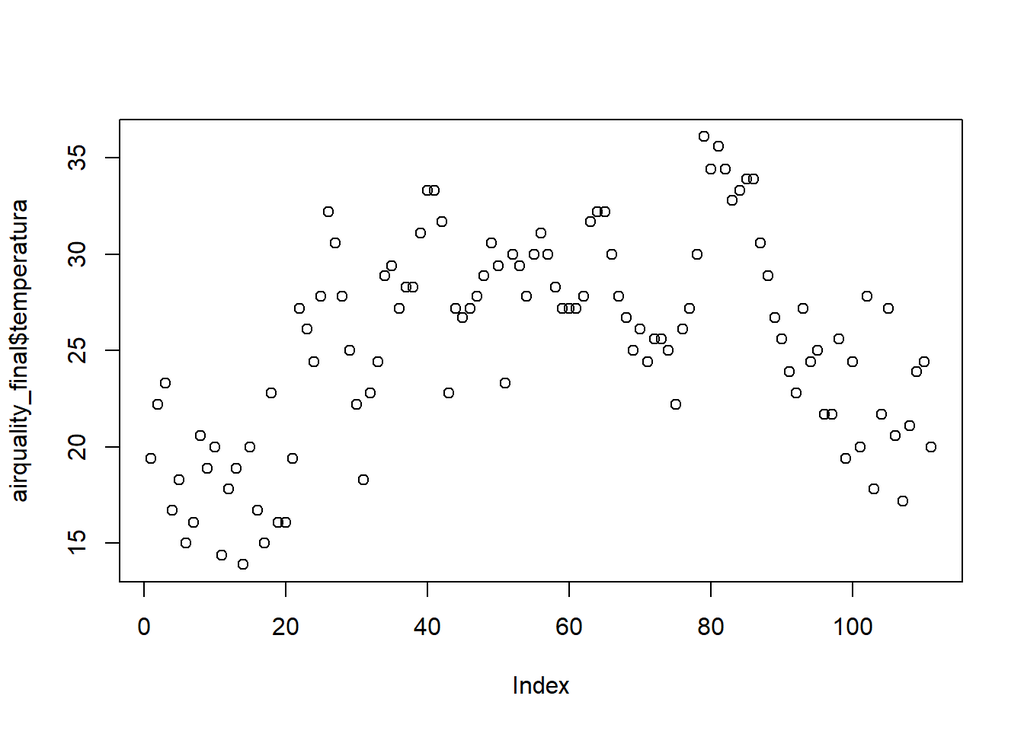

```r
plot(airquality_final$temperatura)
```

Warto mieć na uwadze, że struktura tworzenia wykresów jest bardzo podobna i zależy przede wszystkim od tego, jakie dane przyjmuje wykres (czy jedną zmienną, tak jak w przypadku histogramu, czy też dwie zmienne, tak jak w przypadku wykresu rozrzutu). Pozostałe elementy to stylizacja wykresu, poprzez dodanie argumentów w funkcji, np. col (kolor), main (tytuł), xlab i ylab (podpisy osi X i Y) i wiele innych.

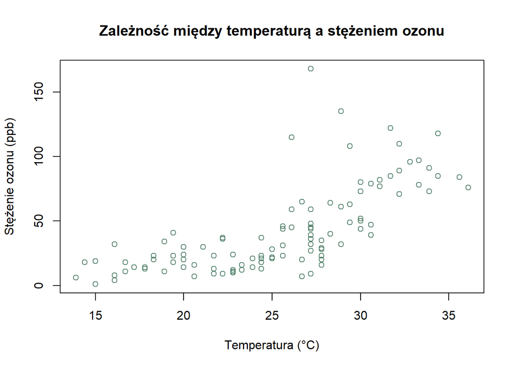

```r
plot(airquality_final$temperatura, airquality_final$stezenie_ozonu, col = "#57856e",
     main = "Zależność między temperaturą a stężeniem ozonu",
     xlab = "Temperatura (°C)", ylab = "Stężenie ozonu (ppb)")
```

**Warto pamiętać, aby wykresy były tworzone poprawnie – dobierając odpowiedni typ do danych, dbając o czytelność oraz unikając manipulacji wizualnej, która może wprowadzać odbiorcę w błąd.**

##### ggplot2

Tworzenie wykresów za pomocą pakietu **ggplot2** ma bardzo podobne zasady – istnieją różne funkcje dla różnego typu wykresów, np. `geom_point()` (wykres rozrzutu), `geom_bar()` (wykres słupkowy), czy `geom_line()` (wykres liniowy). Nie wystarczy jednak ich zwykłe użycie, tak jak w bazowym języku R – trzeba najpierw zdefiniować wykres za pomocą funkcji **ggplot(data, aes(x, y)) + wybrany_rodzaj_wykresu**, gdzie:

- **data** – określa ramkę danych
- **aes()** – określa jak zmienne będą wpływały na różne elementy wykresu
  - **wewnątrz aes()** – wartość zależy od danych (np. kolor według innej zmiennej)
  - **poza aes()** – wartość jest stała (np. wszystkie punkty czerwone)
- **aes(x, y)** – określa zmienne na osiach (x - zmienna 1, y - zmienna 2)
- **wybrany_rodzaj_wykresu** – geom_point(), geom_line() itd.

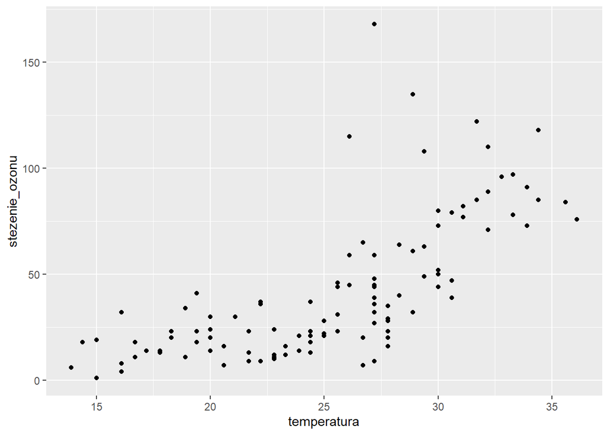

```r
ggplot(airquality_final, aes(x = temperatura, y = stezenie_ozonu)) +
  geom_point()
```

Kolejnymi krokami jest dodanie wszelkich innych warstw lub stylów, tak jak w bazowym R, za pomocą znaku dodawania `+`. Argumenty te nie znajdują się w funkcji `ggplot()`, a są dodawane w poszczególnych funkcjach po znaku `+`, np. za pomocą funkcji `labs()` (podpisy osi i tytuły) czy `theme()` (motywy, opcje czcionek, palet itd.).

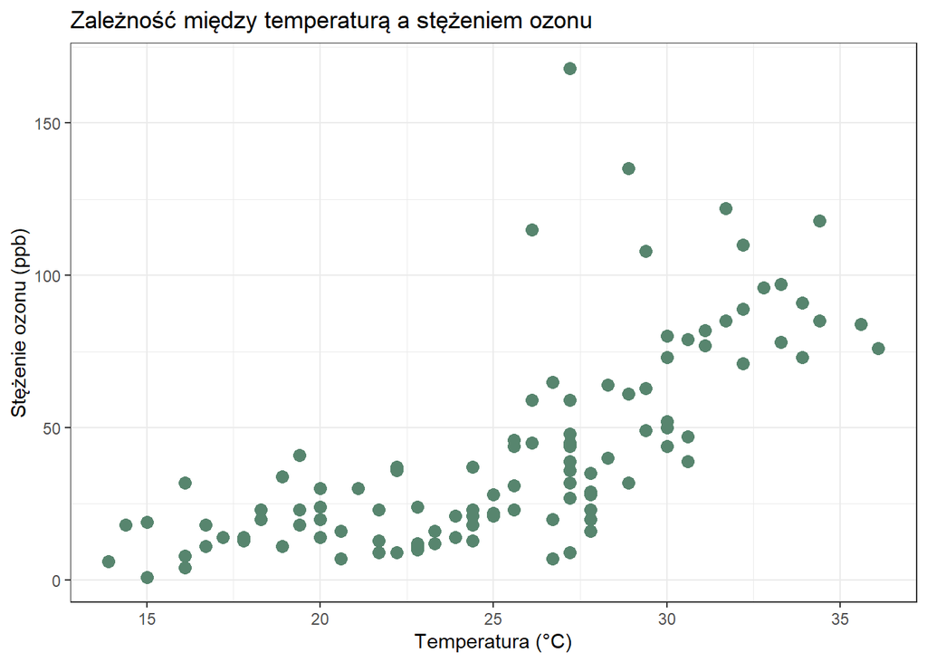

```r
ggplot(airquality_final, aes(x = temperatura, y = stezenie_ozonu)) +
  geom_point(color = "#57856e", size = 3) +
  labs(title = "Zależność między temperaturą a stężeniem ozonu",
       x = "Temperatura (°C)", y = "Stężenie ozonu (ppb)") +
  theme_bw()
```

#### Wykres słupkowy

Wykres słupkowy (bar plot) służy do przedstawienia zbioru danych w formie kategorycznych słupków, prezentujących liczebność lub wartości tych kategorii. Jest główną metodą prezentacji zmiennych jakościowych (kategorycznych), która pomaga dostrzec różnice pomiędzy prezentującymi kategoriami.

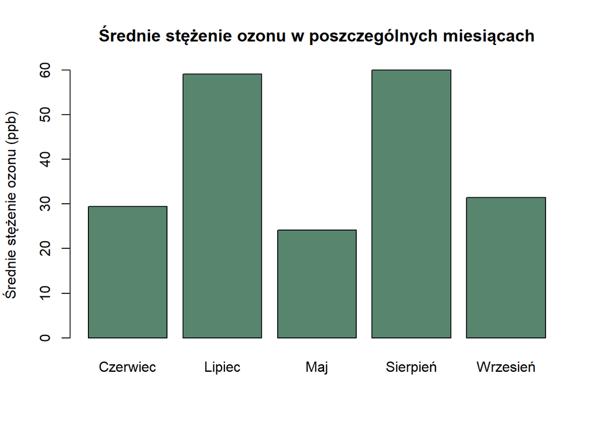

```r
airquality_avg <- airquality_final %>%
  group_by(miesiac) %>%
  summarise(srednie_stezenie_ozonu = mean(stezenie_ozonu, na.rm = TRUE))

# użycie bazowego R
barplot(airquality_avg$srednie_stezenie_ozonu, names.arg = airquality_avg$miesiac,
        col = "#57856e", main = "Średnie stężenie ozonu w poszczególnych miesiącach",
        ylab = "Średnie stężenie ozonu (ppb)")
```

Możemy zauważyć, że miesiące nie wyświetlają się w kolejności występowania, dlatego najlepiej to zmienić. W takich sytuacjach bardzo przydatną funkcją jest utworzenie czynnika (factor), który będzie przechowywał informacje o poziomach (klasach) kolumny `miesiąc`w ustalonej chronologii:

```r
airquality_avg$miesiac <- factor(airquality_avg$miesiac,
                                 levels = c("Maj", "Czerwiec", "Lipiec", "Sierpień", "Wrzesień"))
```

Wizualnie w naszej kolumnie nic się nie zmieniło, natomiast cała kolumna została zaktualizowana o poziomy (levels) w odpowiedniej kolejności:

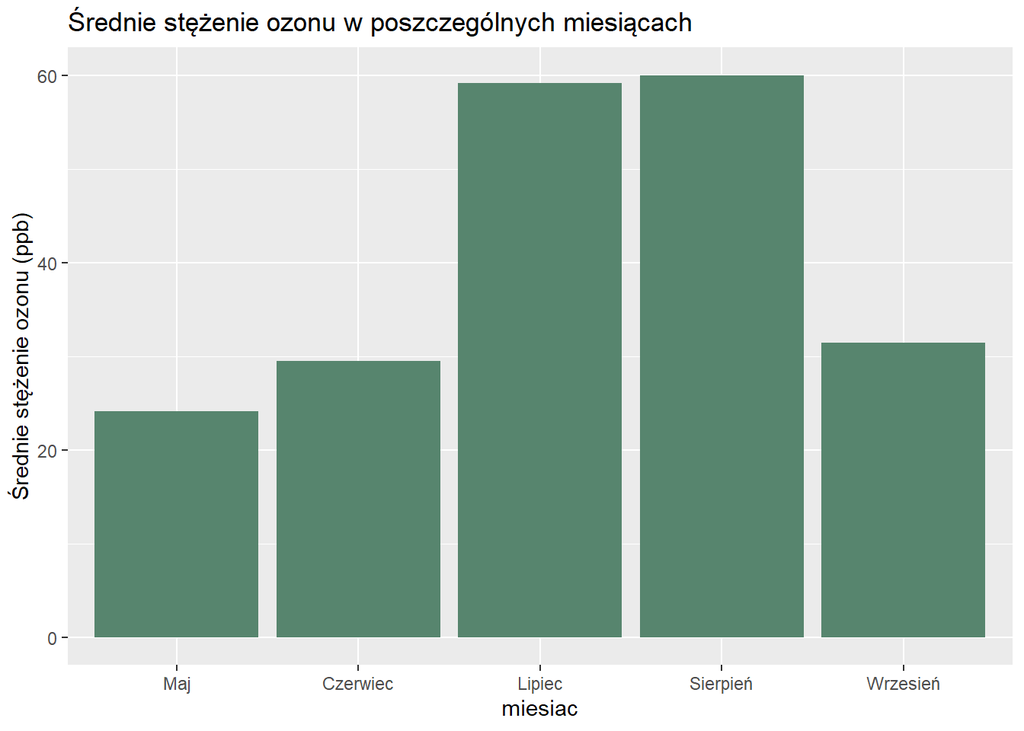

```r
# użycie ggplot2
ggplot(airquality_avg, aes(x = miesiac, y = srednie_stezenie_ozonu)) +
  geom_bar(stat = "identity", fill = "#57856e") +
  labs(title = "Średnie stężenie ozonu w poszczególnych miesiącach",
       y = "Średnie stężenie ozonu (ppb)")
```

Należy pamiętać, że w wykresie słupkowym z pakietu `ggplot2` (`geom_bar()`) występuje parametr `stat`, określa sposób obliczania wartości na osi y. Możemy wybrać różne opcje w zależności od tego, co chcemy przedstawić na wykresie:

- **count** – gdy chcemy policzyć wystąpienia kategorii
- **identity** – gdy posiadamy gotowe wartości (np. średnie, sumy – tak jak w powyżsyzm przypadku)
- **summary** – gdy chcemy automatycznie agregować dane na wykresie

#### Wykres liniowy

Wykres liniowy jest stosowany do prezentacji trendów i zmian zmiennej w czasie. Za jego pomocą możemy zaprezentować m.in. zmienność temperatury w wybranym miesiącu, np. we wrześniu:

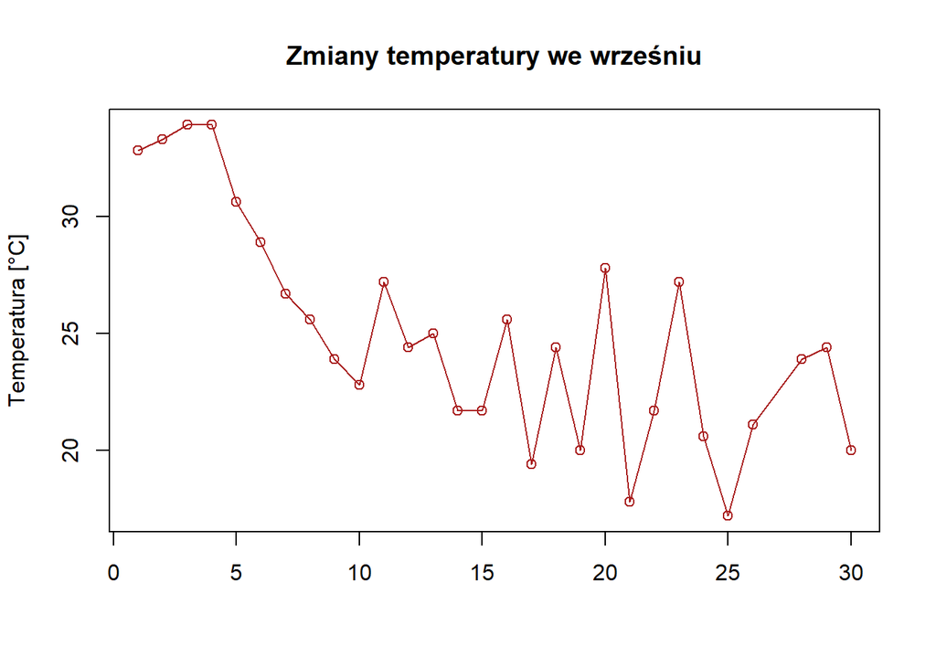

```r
airquality_wrzesien <- airquality_final %>% filter(miesiac == "Wrzesień")

# użycie bazowego R
plot(airquality_wrzesien$dzien, airquality_wrzesien$temperatura,
     type = "o", col = "#a91e1e",
     main = "Zmiany temperatury we wrześniu",
     xlab = " ", ylab = "Temperatura [°C]")
```

Możemy do wykresu dodać także pozostałe zmienne dotyczące prędkości wiatru i stężenia ozonu:

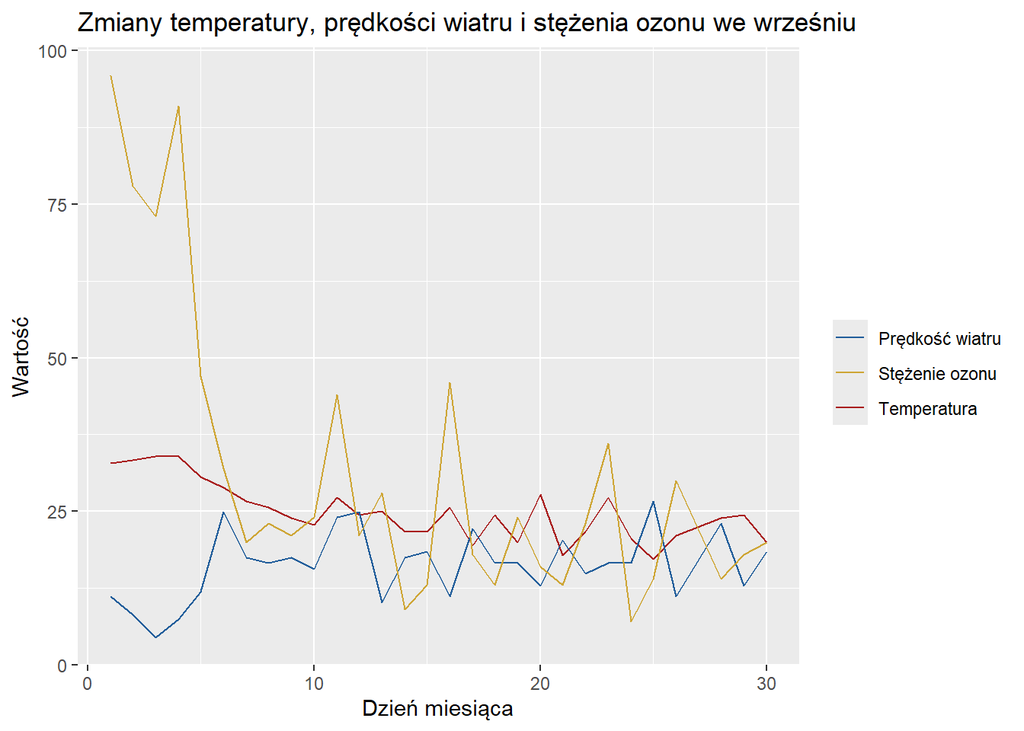

```r
# użycie ggplot2
ggplot(airquality_wrzesien, aes(x = dzien)) +
  geom_line(aes(y = temperatura, color = "Temperatura")) +
  geom_line(aes(y = sila_wiatru, color = "Prędkość wiatru")) +
  geom_line(aes(y = stezenie_ozonu, color = "Stężenie ozonu")) +
  labs(title = "Zmiany temperatury, prędkości wiatru i stężenia ozonu we wrześniu",
       x = "Dzień miesiąca", y = "Wartość", color = " ") +
  scale_color_manual(values = c("Temperatura" = "#a91e1e",            # dodanie ręcznych etykiet kolorów
                                "Prędkość wiatru" = "#225e9b",
                                "Stężenie ozonu" = "#cea636"))
```

#### Wykres rozrzutu

Wykres rozrzutu (scatter plot) to wykres punktowy, przedstawiający zależność jednej zmiennej ciągłej od drugiej. Na jego podstawie możemy określić, czy zmienne te są ze sobą skorelowane, a jeśli tak – jak silna korelacja jest między nimi.

Za jego pomocą możemy zaprezentować m.in. zależność temperatury od stężenia ozonu, co zostało już zaprezentowane przy omawianiu tworzenia wykresów. Dlatego też dodamy do wykresu podział na miesiące.

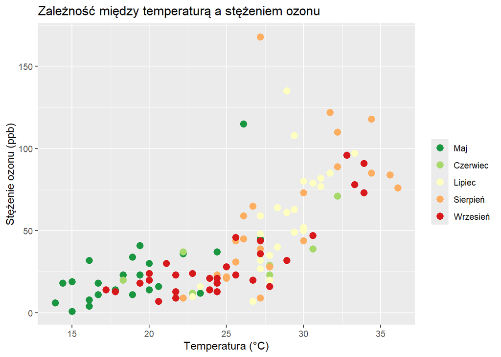

```r
airquality_final$miesiac <- factor(airquality_final$miesiac,
                                 levels = c("Maj", "Czerwiec", "Lipiec", "Sierpień", "Wrzesień"))

ggplot(airquality_final, aes(x = temperatura, y = stezenie_ozonu, color = miesiac)) +
  geom_point(size = 3) +
  labs(title = "Zależność między temperaturą a stężeniem ozonu",
       x = "Temperatura (°C)", y = "Stężenie ozonu (ppb)", color = " ") +
 scale_color_brewer(palette = "RdYlGn", direction = -1)       # dodanie palety kolorów
```

Na podstawie rozłożenia obserwacji możemy określić, że istnieje dość dobra korelacja między obiema zmiennymi – czym większa temperatura, tym występowało wyższe stężenie ozonu. Warto jednak pamiętać, że **korelacja nie oznacza przyczynowości** danego zjawiska.

Jeśli chcielibyśmy obliczyć dokładną korelację między tymi zmiennymi, możemy skorzystać z funkcji `cor()` z pakietu `stats`, automatycznie ładowanego podczas uruchamiania R:

```r
cor(airquality_final$stezenie_ozonu, airquality_final$temperatura)
```

```
[1] 0.6978407
```

#### Wykres pudełkowy

Wykres pudełkowy (box plot) przedstawia rozkład danych oparty na pięciu statystykach: *minimum*, *pierwszym kwartylu (Q1)*, *medianie*, *trzecim kwartylu (Q3)* oraz *maksimum*. Wykres ten stosuje się w celu identyfikacji wartości odstających oraz porównaniu rozkładu danych kilku grup. Aby wykres został poprawnie odczytany, należy wiedzieć, co oznaczają poszczególne jego elementy:

- **środkowa linia** – mediana, dzieli zestaw danych na dwie równe części
- **pudełko** – zakres międzykwartylowy(IQR), zawiera środkowe 50% danych (od Q1 do Q3)
- **linie odchodzące z pudełka (tzw. wąsy)** – górny oraz dolny zakres wartości bez wartości odstających, ich długość definiuje się jako *1.5* * *IQR powyżej Q3 i poniżej Q1*
- **kropki poza wąsami** – wartości odstające, znacznie odbiegają od pozostałych wartości

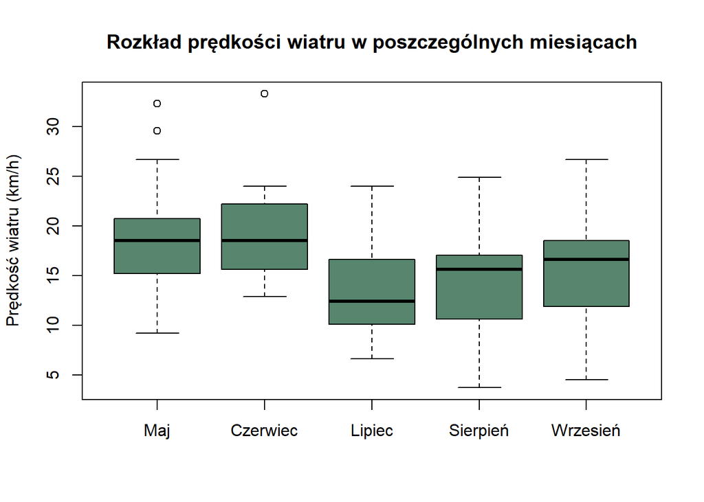

```r
# użycie bazowego R
boxplot(sila_wiatru ~ miesiac, data = airquality_final, col = "#57856e",
        main = "Rozkład prędkości wiatru w poszczególnych miesiącach",
        xlab = " ", ylab = "Prędkość wiatru (km/h)")
```

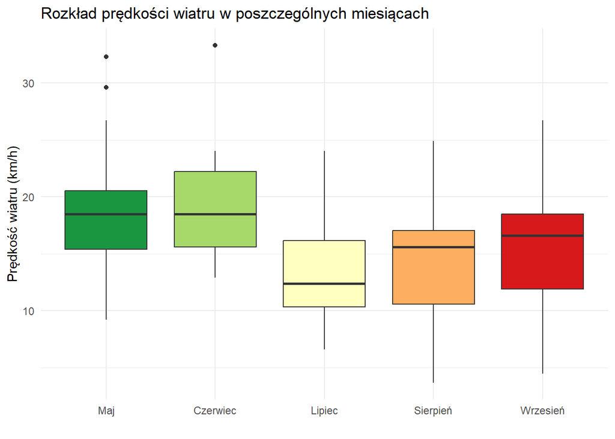

```r
# użycie ggplot2
ggplot(airquality_final, aes(x = miesiac, y = sila_wiatru, fill = miesiac)) +
  geom_boxplot() +
  labs(title = "Rozkład prędkości wiatru w poszczególnych miesiącach",
       x = " ", y = "Prędkość wiatru (km/h)", fill = "") +
  scale_fill_brewer(palette = "RdYlGn", direction = -1) +
  theme_minimal() +
  theme(legend.position = "none")    # usunięcie legendy
```

#### Histogram

Histogram reprezentuje rozkład wartości jednej zmiennej ciągłej, przedstawiając w ten sposób więcej informacji o samym rozkładzie niż wykres pudełkowy. Składa się z słupków, których wysokość odpowiada liczbie obserwacji (częstości) w danym przedziale wartości (tzw. “bin”)

Dla przykładu zaprezentowano poniżej histogram dla temperatury we wszystkich badanych miesiącach.

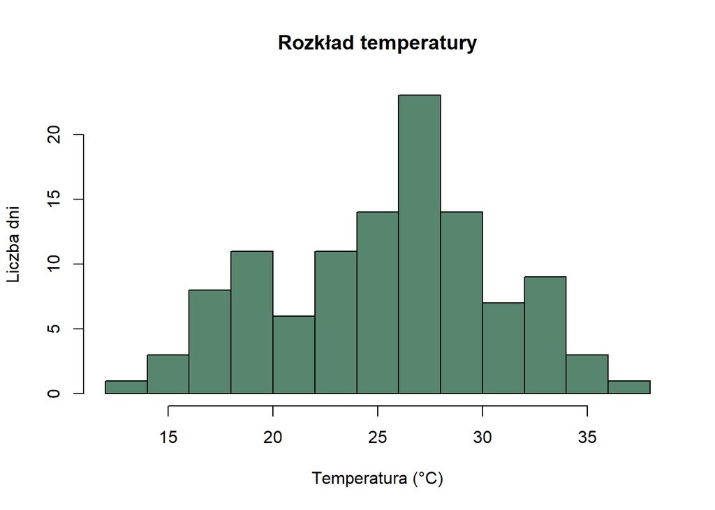

```r
# użycie bazowego R
hist(airquality_final$temperatura,
     breaks = 15, col = "#57856e", main = "Rozkład temperatury",
     xlab = "Temperatura (°C)", ylab = "Liczba dni")
```

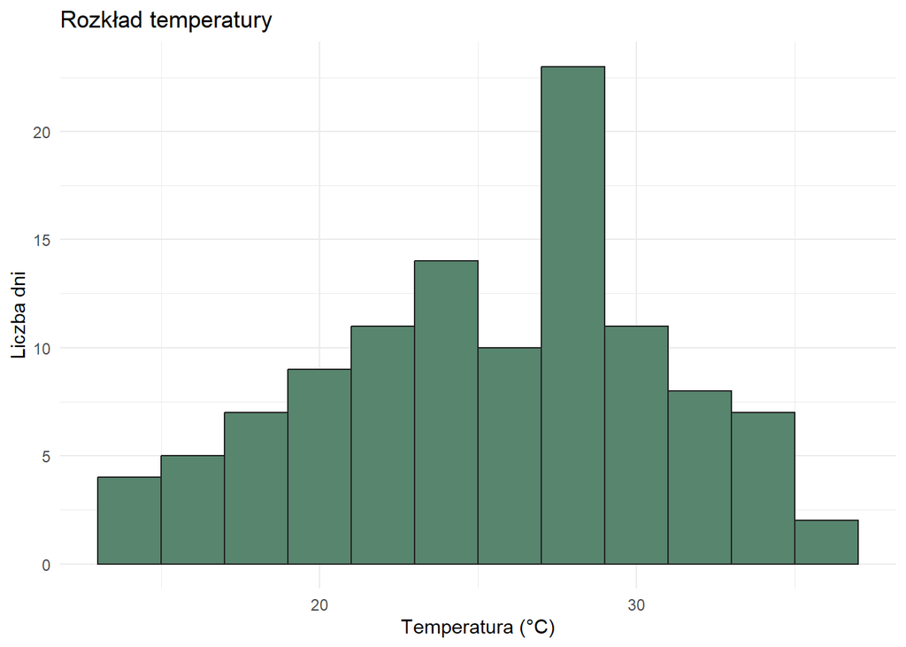

```r
# użycie ggplot2
ggplot(airquality_final, aes(x = temperatura)) +
  geom_histogram(binwidth = 2, fill = "#57856e", color = "#222222") +
  labs(title = "Rozkład temperatury", x = "Temperatura (°C)", y = "Liczba dni") +
  theme_minimal()
```

Często jako zamiennik histogramu wykorzystuje się **wykres gęstości**, czyli jego wygładzoną wersję, która zamiast przedziałów ukazuje krzywą ciągłą przedstawiającą względną częstość występowania wartości.

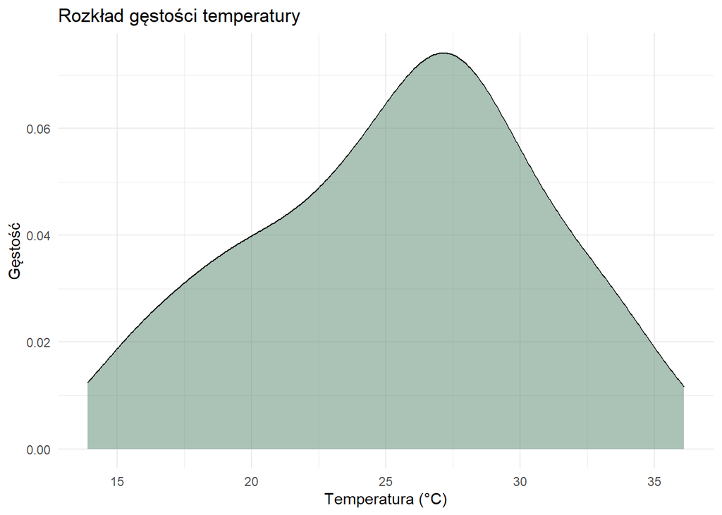

```r
# użycie ggplot2
ggplot(airquality_final, aes(x = temperatura)) +
  geom_density(fill = "#57856e", alpha = 0.5) +
  labs(title = "Rozkład gęstości temperatury", x = "Temperatura (°C)", y = "Gęstość") +
  theme_minimal()
```

#### Łączenie wykresów

Istnieje wiele opcji generowania osobnych wykresów dla kilku zmiennych jednocześnie, a także łączenia kilku wykresów na jednej rycinie. Najpopularniejszymi pakietami do łączenia wykresów są m.in.: `patchwork`, `gridExtra`, `cowplot`, czy też `ggpubr`. Każdy z nich oferuje inne możliwości i poziom zaawansowania.

Jeśli chcielibyśmy wygenerować kilka wykresów jednocześnie bez manualnego łączenia ich na jednej rycinie, możemy skorzystać z funkcji `facet_wrap()` z pakietu `ggplot2`. Poniżej zaprezentowano przykład jej użycia w celu wygenerowania zależności między temperaturą a prędkością wiatru dla każdego miesiąca:

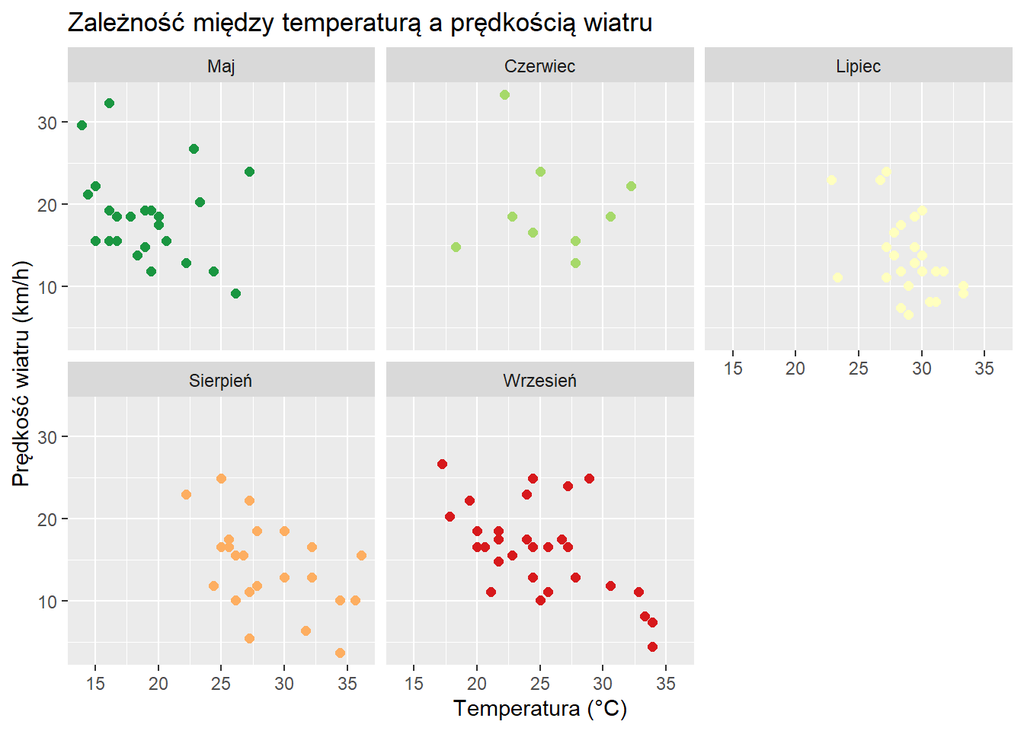

```r
# użycie ggplot2
ggplot(airquality_final, aes(x = temperatura, y = sila_wiatru, color = miesiac)) +
  geom_point(size = 2) +
  facet_wrap(~ miesiac) +                  # Podział na panele według miesiąca
  labs(title = "Zależność między temperaturą a prędkością wiatru",
       x = "Temperatura (°C)", y = "Prędkość wiatru (km/h)") +
  scale_color_brewer(palette = "RdYlGn", direction = -1) + theme(legend.position = "none")
```

# Zadania

W oparciu o wiedzę z 1 i 2 zajęć wykonaj poniższą eksplorację danych:

### Zadanie 1

Pobierz, wypakuj oraz wczytaj plik .csv ([Link do danych](https://raw.githubusercontent.com/Adrian-Nowacki/kurs_uo/main/dane/02_Eksploracja_danych/co2_emissions.zip)) obejmujący informacje o emisji CO2 w krajach Unii Europejskiej w latach 1792-2023. Pamiętaj, aby wskazać poprawną ścieżkę do pobranego pliku względem lokalizacji skryptu R.

**Pokaż kod**

```r
library(tidyverse)
data <- read.csv("02_eksploracja_danych/co2_emissions.csv")
```

### Zadanie 2

Sprawdź strukturę danych oraz typ kolumn – pamiętaj, że aby cokolwiek obliczać lub wizualizować na zmiennych ciągłych, kolumny muszą mieć typ liczbowy. Sprawdź, czy występują jakiekolwiek braki (NA) – jeśli tak, usuń je. Następnie zmień nazwy kolumn na polskie tłumaczenia oraz usuń niepotrzebną kolumnę z kodem.

**Pokaż kod**

```r
# sprawdzenie struktury i braków danych
str(data)
colSums(is.na(data))
data <- na.omit(data)

# zmiana nazw kolumn
colnames(data)
colnames(data) <- c("panstwo", "kod", "rok", "emisja_co2", "region")
colnames(data)

# usunięcie kolumny kod
data <- data %>% select(-kod)
```

### Zadanie 3

Zaktualizuj kolumnę z nazwami regionów tak, aby zmienić ich nazwy na polskie tłumaczenia.

**Pokaż kod**

```r
# zbadanie unikalnych wartości
unique(data$region)

# klasyfikacja
data <- data %>%
  mutate(region = case_when(
    region == "Eastern Europe"   ~ "Europa Wschodnia",
    region == "Northern Europe"  ~ "Europa Północna",
    region == "Southern Europe"  ~ "Europa Południowa",
    region == "Western Europe"   ~ "Europa Zachodnia",
    TRUE ~ "Pozostałe"
  ))
```

### Zadanie 4

Ze zbioru danych wybierz jedynie obserwacje dla 2000 roku i powyżej. Następnie nadpisz kolumnę z emisją CO2 w taki sposób, aby jej wartości (aktualnie w tonach) były podane w milionach ton do 3 miejsc po przecinku.

**Pokaż kod**

```r
# filtrowanie
data_selected <- data %>% filter(rok >= 2000)

# zmiana na miliony ton
data_selected$emisja_co2 <- round(data_selected$emisja_co2 / 1000000, 3)
```

### Zadanie 5

Z przefiltrowanej ramki danych, korzystając z grupowania i agregacji, stwórz nową ramkę danych w oparciu o poniższe warunki i wyświetl 3 najbardziej emisyjne kraje i regiony:

- suma emisji CO2 dla każdego kraju

**Pokaż kod**

```r
# obliczenie sumy emisji dla państw
mean_country_co2 <- data_selected %>%
  group_by(panstwo) %>%
  summarise(suma_emisji = sum(emisja_co2))

# wyświetlenie 3 rekordów
mean_country_co2 %>% arrange(desc(suma_emisji)) %>% head(3)
```

- średnią roczną emisję CO2 dla każdego regionu

**Pokaż kod**

```r
# obliczenie średniej emisji dla regionów
mean_region_co2 <- data_selected %>%
  group_by(region) %>%
  summarise(srednia_emisja = mean(emisja_co2))

# wyświetlenie 3 rekordów
mean_region_co2 %>% arrange(desc(srednia_emisja)) %>% head(3)
```

### Zadanie 6

**Pokaż kod**

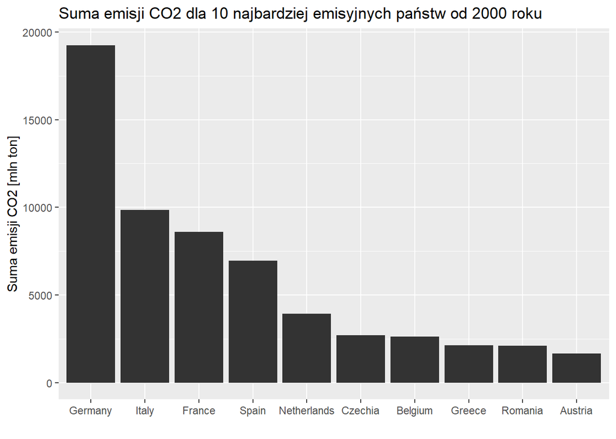

```r
# wybór 10 najbardziej emisyjnych państw
top10_country_co2 <- mean_country_co2 %>%
  arrange(desc(suma_emisji)) %>% head(10)

# ustawienie wartości malejąco za pomocą czynnika
top10_country_co2$panstwo <- factor(top10_country_co2$panstwo,
                                     levels = top10_country_co2$panstwo)

# wykres słupkowy
ggplot(top10_country_co2, aes(x = panstwo, y = suma_emisji)) +
  geom_bar(stat = "identity", fill = "#333333") +
  labs(title = "Suma emisji CO2 dla 10 najbardziej emisyjnych państw od 2000 roku",
       y = "Suma emisji CO2 [mln ton]", x = "")
```

### Zadanie 7

W oparciu o ramkę danych z 3 zadania wykonaj grupowanie i agregację tak, aby uzyskać zsumowane wartości CO2 dla państwa w danym roku. Zwizualizuj następnie trend emisji CO2 dla 10 najbardziej emisyjnych państw.

**Pokaż kod**

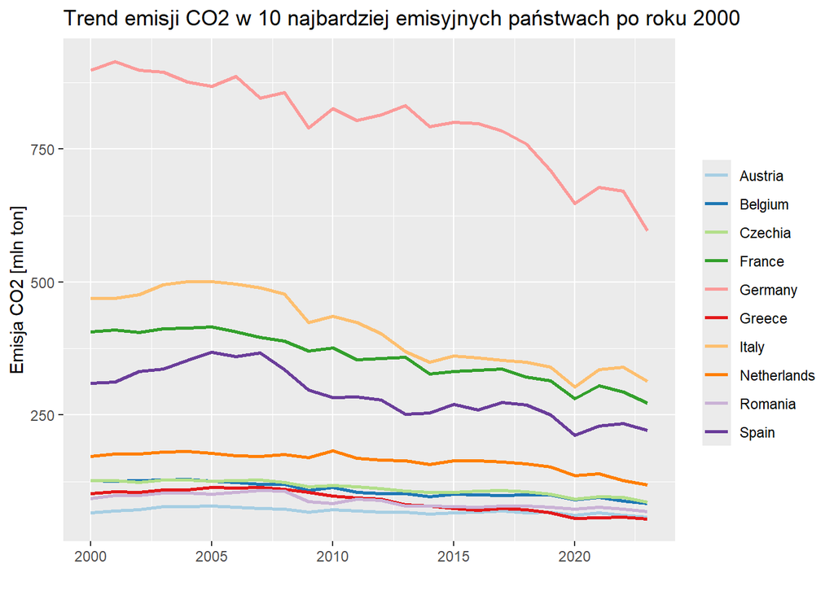

```r
# grupowanie w oparciu o rok i państwo oraz obliczenie sumy emisji
trend_country <- data_selected %>%
  group_by(rok, panstwo) %>%
  summarise(suma_emisji = sum(emisja_co2))

# wybór danych dla 10 najbardziej emisyjnych państw
trend_top10 <- trend_country %>% filter(panstwo %in% unique(top10_country_co2$panstwo))

# wykres liniowy
ggplot(trend_top10, aes(x = rok, y = suma_emisji, color = panstwo)) +
  geom_line(size = 1) +
  labs(title = "Trend emisji CO2 w 10 najbardziej emisyjnych państwach po roku 2000", x = "", y = "Emisja CO2 [mln ton]", color = "")  + scale_color_brewer(palette = "Paired")
```

### Zadanie 8

W oparciu o ramkę danych z 3 zadania przedstaw rozkład emisji CO2 dla regionów w formie wykresu pudełkowego.

**Pokaż kod**

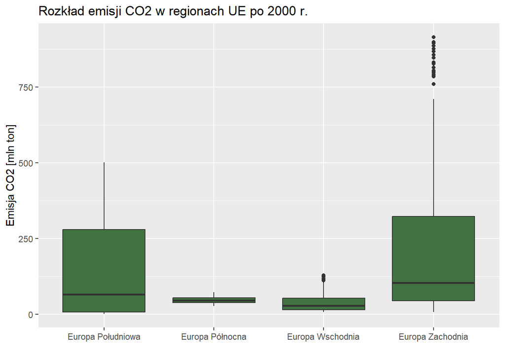

```r
# wykres pudełkowy
ggplot(data_selected, aes(x = region, y = emisja_co2)) +
  geom_boxplot(fill = "#417342") +
  labs(
    title = "Rozkład emisji CO2 w regionach UE po 2000 r.",
    x = "",
    y = "Emisja CO2 [mln ton]"
  ) + theme(legend.position = "none")
```